# TFA exam solution (R part)

Lars Relund Nielsen

# R - Assignment 1 (14%)

## Question 1

Make functions:

- `SecToMin` which takes an input argument `sec` in seconds and return the number converted to minutes.
- `SecToHours` which takes an input argument `sec` in seconds and return the number converted to hours.
- `MinToSec` which takes an input argument `min` in minutes and return the number converted to seconds.
- `MinToHours` which takes an input argument `min` in minutes and return the number converted to hours.
- `HoursToMin` which takes an input argument `hours` in hours and return the number converted to minutes.
- `HoursToSec` which takes an input argument `hours` in hours and return the number converted to seconds.

All numbers may be decimal numbers, e.g. 90 seconds is 1.5 minutes and 1.5 hours is 90 minutes.

Guiding solution:

```r
SecToMin <- function(sec) {
   return(sec / 60)
}

SecToHours <- function(sec) {
   return(sec / 60 / 60)
}

MinToSec <- function(min) {
   return(min * 60)
}

MinToHours <- function(min) {
   return(min / 60)
}

HoursToMin <- function(hours) {
   return(hours * 60)
}

HoursToSec <- function(hours) {
   return(hours * 60 * 60)
}
```

## Question 2

Make a function `ConvertTime` which takes two input arguments:

- `val` A number.
- `unit` A string that can take values “sec”, “min” and “hours”.

The function should return `val` converted to seconds, minutes and hours with features:

- works for all possible values for `unit`,
- uses the functions in Question 1,
- returns a vector with 3 numbers (seconds, minutes and hours) or `NA` if `unit` does not equals “sec”, “min” or “hours”.

Guiding solution:

```r
ConvertTime <- function(val, unit) {
   if (unit == "sec") {
      return(c(sec = val, min = SecToMin(val), hours = SecToHours(val)))
   }
   if (unit == "min") {
      return(c(sec = MinToSec(val), min = val, hours = MinToHours(val)))
   }
   if (unit == "hours") {
      return(c(sec = HoursToSec(val), min = HoursToMin(val), hours = val))
   }
   return(NA)
}
## We test the function:
ConvertTime(val = 1.5, unit = "min")
```

```
##    sec    min  hours
## 90.000  1.500  0.025
```

```r
ConvertTime(val = 1.5, unit = "hours")
```

```
##    sec    min  hours
## 5400.0   90.0    1.5
```

```r
ConvertTime(val = 1.5, unit = "kr")
```

```
## [1] NA
```

# R - Assignment 2 (18%)

The dataset in the file `election.csv` lists election votes for municipal elections in Denmark. The column/variables are:

- `area`: municipality,
- `party`: political party,
- `year`: election year,
- `validVotes`: Number of (valid) votes,
- `personalVotes`: total number of personal votes,
- `listedMen`: men listed,
- `listedWomen`: women listed,
- `electedMen`: elected men,
- `electedWomen`: elected women.

You can read the dataset file into the dataset `dat` using

```r
library(tidyverse)
dat <- read_csv("elections.csv")
```

Use the *dplyr* package in *tidyverse* to calculate relevant summary tables (data frames) and answer the following questions.

## Question 1

How many different municipalities were there in Denmark in 2017?

Guiding solution:

```r
res <- dat %>%
  filter(year == 2017) %>%
  distinct(area) %>%
  nrow() %>%
  print()
```

```
## [1] 99
```

We have a total of 99 municipalities.

## Question 2

In which election year was the total number of votes highest?

Guiding solution:

```r
res <- dat %>%
  group_by(year) %>%
  summarize(votes = sum(validVotes)) %>%
  arrange(desc(votes)) %>%
  print()
```

```
## # A tibble: 4 × 2
##    year   votes
##   <dbl>   <dbl>
## 1  2017 3176021
## 2  2013 3116083
## 3  2005 2880007
## 4  2009 2784466
```

The highest number of votes was in 2017.

## Question 3

Consider the 2017 election. How many votes and elected candidates did the different parties get in total (sort your result descending by votes)?

Guiding solution:

```r
res <- dat %>%
  filter(year == 2017) %>%
  mutate(elected = electedMen + electedWomen) %>%
  group_by(party) %>%
  summarize(votes = sum(validVotes), elected = sum(elected)) %>%
  arrange(desc(votes)) %>%
  print()
```

```
## # A tibble: 12 × 3
##    party                          votes elected
##    <chr>                          <dbl>   <dbl>
##  1 Social Democratic Party      1029326     842
##  2 Liberal Democratic Party      733484     688
##  3 Conservative Peoples Party    279041     225
##  4 Danish Peoples Party (1997-)  277656     223
##  5 Unity List                    188987     102
##  6 Socialist Peoples Party       181591     126
##  7 Social Liberal Party          146707      80
##  8 Letters not reserved, total   124912      87
##  9 The Alternative                93426      20
## 10 Liberal Alliance               82110      28
## 11 Nye Borgerlige                 29073       1
## 12 The Slesvig Party               9708      10
```

The highest number of votes was given to the Social Democratic Party (1029326 votes) who got 842 elected.

## Question 4

Calculate the percentage of females listed for each year. Are there on average more women than men listed? Is there any tendency over the years?

Guiding solution:

```r
res <- dat %>%
  group_by(year) %>%
  summarize(listedWomen = sum(listedWomen), listedMen = sum(listedMen)) %>%
  mutate(listedWomenPct = listedWomen/(listedMen + listedWomen)) %>%
  arrange(listedWomenPct) %>%
  print()
```

```
## # A tibble: 4 × 4
##    year listedWomen listedMen listedWomenPct
##   <dbl>       <dbl>     <dbl>          <dbl>
## 1  2005        3374      8033          0.296
## 2  2013        2796      6287          0.308
## 3  2009        2810      6239          0.311
## 4  2017        3037      6519          0.318
```

The listed women is approx. 31. That is, listed women is lower than listed men. This percentage seems to be almost constant over the years (but increasing very slowly).

## Question 5

Consider the 2017 election. In which municipality did the Liberal Democratic Party get the highest percentage of votes?

Guiding solution:

```r
res <- dat %>%
  filter(year == 2017) %>%
  group_by(area) %>%
  mutate(votesPct = validVotes/sum(validVotes)) %>%
  filter(party == "Liberal Democratic Party") %>%
  select(area, party, votesPct) %>%
  arrange(desc(votesPct)) %>%
  print()
```

```
## # A tibble: 99 × 3
## # Groups:   area [99]
##    area       party                    votesPct
##    <chr>      <chr>                       <dbl>
##  1 Herning    Liberal Democratic Party    0.556
##  2 Lemvig     Liberal Democratic Party    0.487
##  3 Morsø      Liberal Democratic Party    0.483
##  4 Nyborg     Liberal Democratic Party    0.475
##  5 Jammerbugt Liberal Democratic Party    0.465
##  6 Kolding    Liberal Democratic Party    0.464
##  7 Tønder     Liberal Democratic Party    0.446
##  8 Assens     Liberal Democratic Party    0.420
##  9 Varde      Liberal Democratic Party    0.420
## 10 Nordfyns   Liberal Democratic Party    0.401
## # … with 89 more rows
```

The Liberal Democratic Party got must relative votes in Herning.

# R - Assignment 3 (18%)

Answer this assignment using the *ggplot2* package in *tidyverse* (you might need dplyr for preparing the datasets you want to plot). We work with the dataset from Assignment 2 which can be read using:

```r
library(tidyverse)
dat <- read_csv("elections.csv")
```

## Question 1

Create a visualization showing the total number of votes for each election year with the following features:

- Number of votes is represented using columns.
- Columns are filled with colours for each party.
- Informative figure title and axis titles are given.

Which year had the lowest number of votes?

Guiding solution:

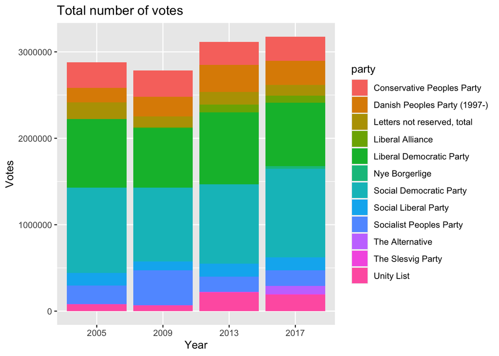

```r
dat %>%
  group_by(year, party) %>%
  summarise(votes = sum(validVotes)) %>%
  ggplot(aes(y = votes, x = factor(year), fill = party)) +
  geom_col() +
  labs(title = "Total number of votes",
       x = "Year",
       y = "Votes"
    )
```

The lowest number of votes was in 2009.

## Question 2

Create a visualization showing the relative number of elected women in each municipality with the following features:

- The relative number of elected women is shown using columns.
- Municipalities are rotated 90 degrees on the x-axis.
- The columns are sorted increasing.
- Informative figure title and axis titles are given.

Which municipality has the lowest/highest percentage of women elected?

Guiding solution:

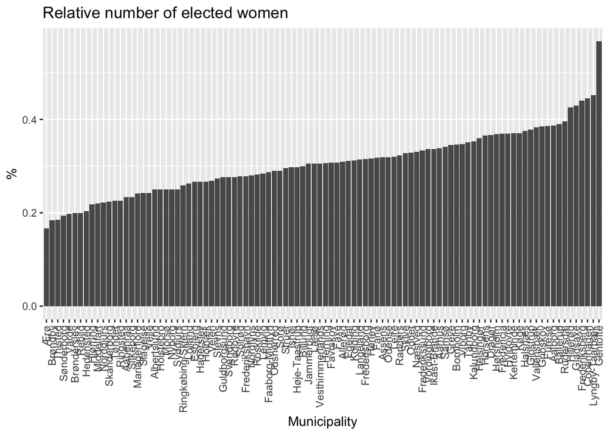

```r
dat %>%
  group_by(area) %>%
  summarize(electedWomen = sum(electedWomen), electedMen = sum(electedMen)) %>%
  mutate(electedWomenPct = electedWomen/(electedMen + electedWomen)) %>%
  filter(!is.na(electedWomenPct)) %>%
  ggplot(aes(x = reorder(area, electedWomenPct), y = electedWomenPct)) +
  geom_col() +
  labs(title = "Relative number of elected women",
       x = "Municipality",
       y = "%"
    ) +
  theme(axis.text.x = element_text(angle = 90, vjust = 0.5, hjust=1))
```

The lowest number elected is in Ærø and the highest is in Gentofte.

## Question 3

Create a visualization showing the elected number of candidates as a function of election year with the following features:

- We consider only municipalities Herning, Copenhagen and Aarhus.
- We consider only the Social Democratic Party, Conservative Peoples Party and Liberal Democratic Party.
- The plot is divided using `area` (facet).
- Different colours are used for each party.
- Informative figure title and axis titles are given.
- Data points are given in the plot.
- A line for each party is added.

Consider the Social Democratic Party in Copenhagen. Based on the plot do the elected number of candidates increase or decrease over the election years?

Guiding solution:

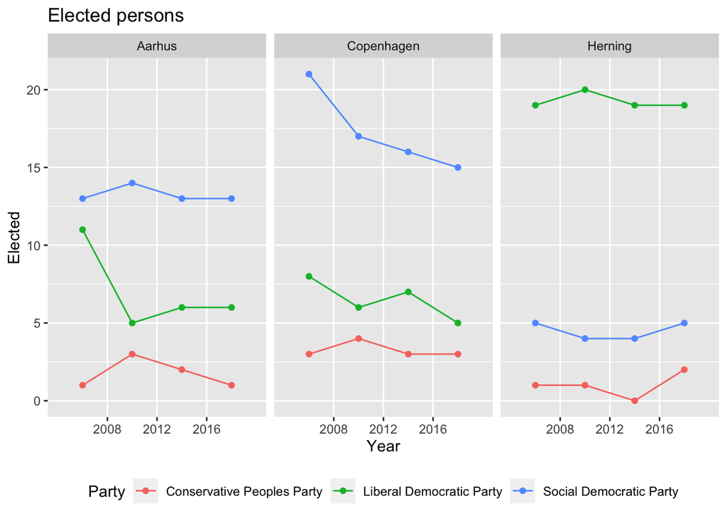

```r
dat %>%
  filter(area %in% c("Herning", "Copenhagen", "Aarhus"), party %in% c("Social Democratic Party", "Conservative Peoples Party", "Liberal Democratic Party")) %>%
  mutate(elected = electedMen + electedWomen) %>%
  ggplot(aes(x = year, y = elected, color = party)) +
  geom_point() +
  geom_line() +
  scale_x_binned(n.breaks = 4, nice.breaks = TRUE) +
  facet_grid(. ~ area) +
  labs(title = "Elected persons",
       x = "Year",
       y = "Elected",
       color = "Party") +
  theme(legend.position = "bottom")
```

The trend for the Social Democratic Party in Copenhagen is decreasing over the years.

## Question 4

Create a visualization showing the relative number of women elected compared to listed (e.g. if listed is 12 and elected is 4 then the number is 4/12) with the following features:

- Columns are used for each party.
- Colours are used to identify the party.
- A sub-plot is given for each year.
- Informative figure title and axis titles are given.

Which party seems to get the highest number of the listed women elected?

Guiding solution:

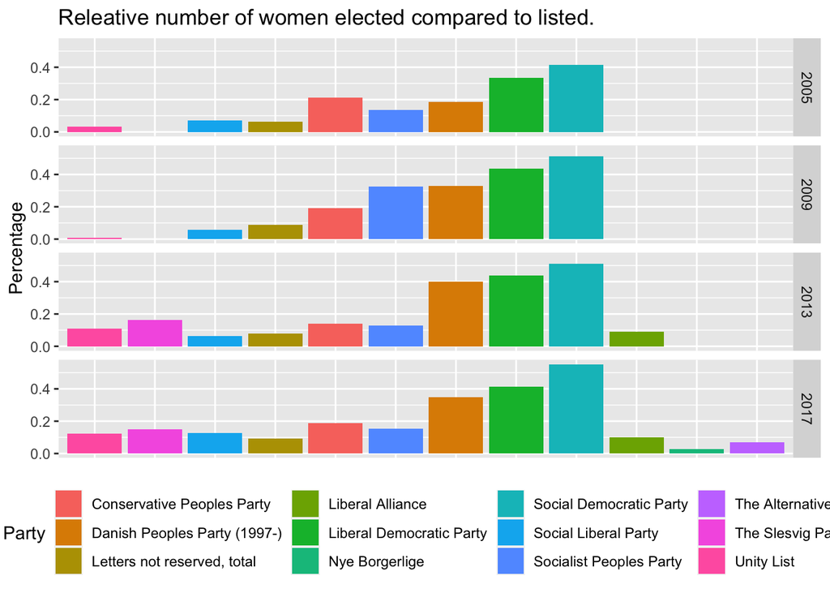

```r
dat %>%
  mutate(electedW = electedWomen/listedWomen) %>%
  group_by(party, year) %>%
  summarize(electedW = mean(electedW, na.rm = T)) %>%
  ggplot(aes(x = reorder(party, electedW), y = electedW, fill = party)) +
  geom_col() +
  facet_grid(year ~ .) +
  labs(title = "Releative number of women elected compared to listed.",
       x = "Party",
       y = "Percentage",
       fill = "Party") +
  theme(axis.title.x=element_blank(),
        axis.text.x=element_blank(),
        axis.ticks.x=element_blank(), legend.position = "bottom")
```

For all years the Social Democratic Party has the highest number of the listed women elected.

## Question 5

Create a visualization showing the variance in the relative number of personal votes compared to valid votes (i.e. divide the two numbers) with the following features:

- We consider only municipalities Herning, Copenhagen and Aarhus.
- Variation is shown using a box-plot for each municipality.
- Informative figure title and axis titles are given.

Which municipality has the highest median?

Guiding solution:

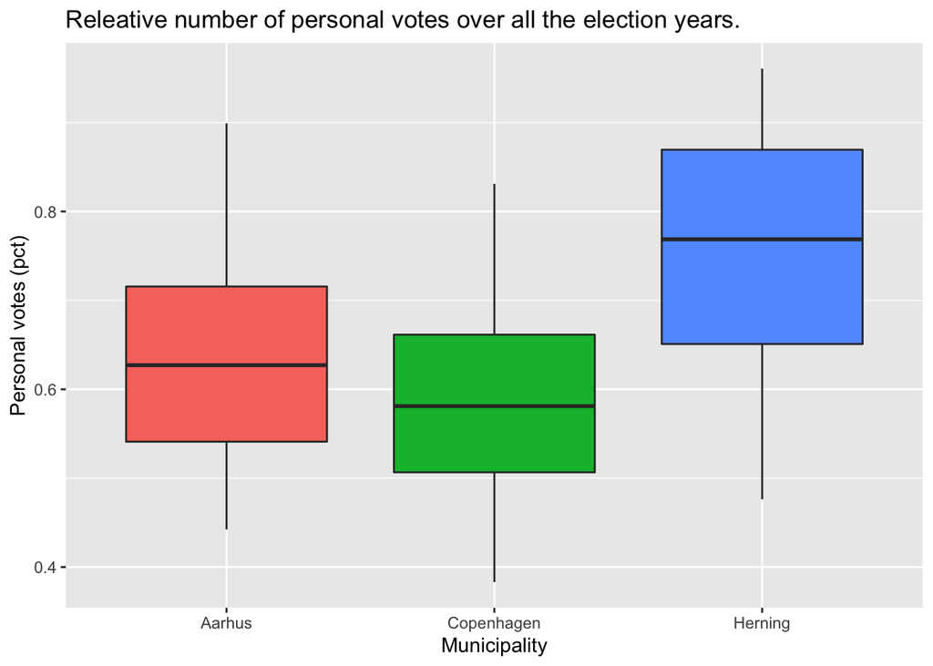

```r
dat %>%
  filter(area %in% c("Herning", "Copenhagen", "Aarhus")) %>%
  mutate(personal = personalVotes/validVotes) %>%
    ggplot(aes(x = area, y = personal, fill = area)) +
    geom_boxplot() +
    labs(title = "Releative number of personal votes over all the election years.",
       x = "Municipality",
       y = "Personal votes (pct)",
       fill = "Municipality") +
    theme(legend.position = "none")
```

Based on the plot Herning has the highest median of personal votes.